# Classification Case-Study

Martin Hanewald

1 August 2018

# 1 Abstract

This analysis is about a classification problem in marketing: how can we find the customer group with the highest potential value, on which to focus ones marketing activities.

This question is answered in two steps:

1. A cluster analysis is conducted on a dataset of historical transactions of the existing customer portfolio in order to separate two groups: **high** and **low** potential customers.
2. A second dataset with demographic information about the existing customers is used to train a classification algorithm to predict the group membership.

# 2 Configuration and libraries

```r
library(tidyverse)
library(caret)
library(lubridate)
library(GGally)
library(rpart.plot)
```

# 3 Clustering

## 3.1 Loading data

```r
orders <- read_csv2('data/orders_sim.csv')
orders
```

| TransactionID | ProductID | CustomerID | Date | OrderTotal |
| --- | --- | --- | --- | --- |
| 10195 | 9256 | 2088 | 2018-08-17 | 86 |
| 10756 | 9257 | 2088 | 2018-07-25 | 63 |
| 10309 | 9258 | 2088 | 2018-07-18 | 119 |
| 10430 | 9257 | 2088 | 2018-06-13 | 181 |
| 10645 | 9252 | 2088 | 2017-11-06 | 101 |
| 10255 | 9258 | 2088 | 2018-06-08 | 119 |
| 10330 | 9258 | 2088 | 2018-03-30 | 122 |
| 10527 | 9259 | 2088 | 2018-06-01 | 182 |
| 10848 | 9256 | 2088 | 2018-03-12 | 90 |
| 10469 | 9254 | 1654 | 2017-12-06 | 77 |

[output cut: 9990 more lines]

## 3.2 Preprocessing

### 3.2.1 Feature engineering

We create three new features from the transactional data via summarising on the CustomerID’s.

1. Recency: Days since last transaction
2. Frequency: Total transaction count
3. Market Value: Total revenue

These are the so called RFM metrics.

```r
RFM <- orders %>%
    mutate_at(vars(CustomerID), as.factor) %>%
    group_by(CustomerID) %>%
    summarise(R = as.integer(Sys.Date() - max(Date)),
              F = n(),
              M = sum(OrderTotal))
RFM
```

| CustomerID | R | F | M |
| --- | --- | --- | --- |
| 1002 | 72 | 9 | 1165 |
| 1003 | 102 | 11 | 1313 |
| 1004 | 116 | 9 | 1174 |
| 1005 | 88 | 9 | 1184 |
| 1006 | 103 | 10 | 1067 |
| 1007 | 66 | 17 | 1710 |
| 1008 | 79 | 15 | 1616 |
| 1009 | 110 | 16 | 2079 |
| 1010 | 83 | 10 | 1250 |
| 1011 | 97 | 9 | 1127 |

[output cut: 1079 more lines]

### 3.2.2 Centering and scaling

For more meaningful exploratory plots we center and scale the RFM matrix.

```r
pre <- preProcess(RFM)
RFM_centered <- predict(pre, RFM)
```

## 3.3 Exploratory analysis

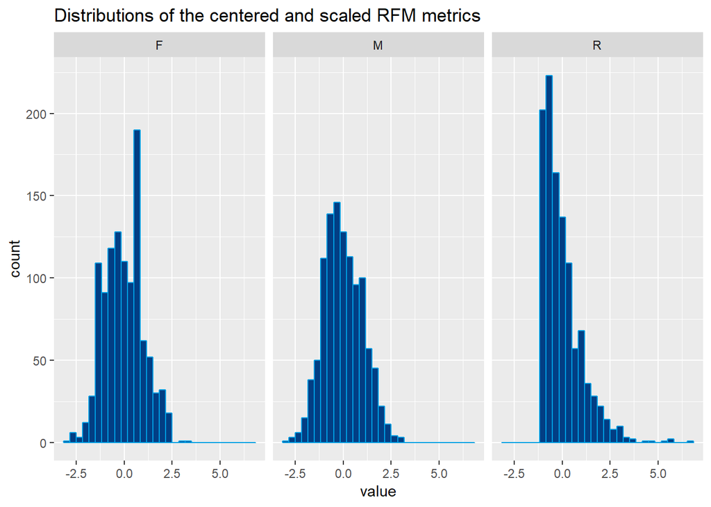

```r
RFM_centered %>% gather(metric, value, -CustomerID) %>%
    ggplot(aes(x=value)) +
        geom_histogram(color = qpal[1], fill = qpal[2]) +
        facet_grid(.~metric) +
        labs(title='Distributions of the centered and scaled RFM metrics')
```

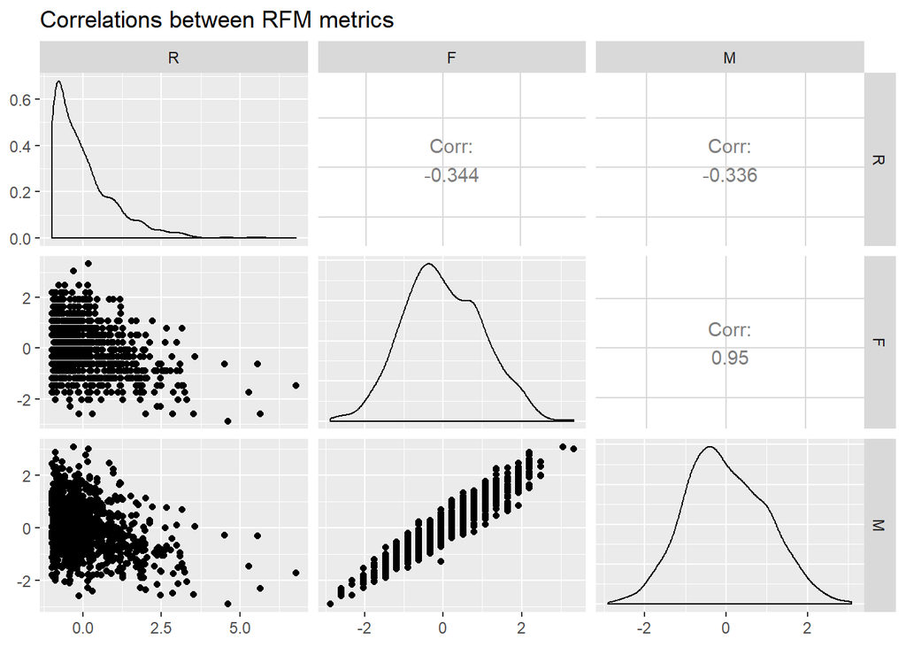

```r
RFM_centered %>%
    select(-CustomerID) %>%
    ggpairs(title='Correlations between RFM metrics')
```

## 3.4 k-means Clustering

Based on the RFM metrics we conduct a k-means clustering with k = 2.

```r
cluster <- RFM %>%
    select(-CustomerID) %>%
    kmeans(2)

cluster
```

```
## K-means clustering with 2 clusters of sizes 481, 608
##
## Cluster means:
##           R         F        M
## 1  88.00624 14.307692 1805.607
## 2 104.72368  8.735197 1051.641
##
## Clustering vector:
##    [1] 2 2 2 2 2 1 1 1 2 2 1 2 1 2 1 2 1 2 2 2 2 2 2 2 2 1 1 1 1 1 2 1 1 2 1 1 2 1 2 1 1 2 2 1 1 1 1 1 1 2 2 1
##   [53] 2 2 2 2 1 2 2 2 2 2 1 1 1 2 2 2 1 2 1 2 2 1 2 1 1 2 1 2 1 2 2 1 2 2 2 2 1 1 2 2 1 2 1 2 1 1 2 2 1 1 2 2
##  [105] 1 1 1 1 2 1 2 2 1 2 1 1 2 1 2 2 2 1 2 1 2 2 2 2 2 2 2 1 2 2 1 2 1 2 2 2 2 1 1 1 1 1 2 2 1 2 2 2 2 1 1 2
##  [157] 1 2 2 2 2 2 2 2 1 2 2 1 1 2 1 2 1 2 2 1 2 1 1 1 1 1 1 1 1 2 2 2 1 2 1 1 2 2 2 1 1 1 2 1 1 2 2 1 1 2 2 2
##  [209] 1 2 1 2 2 1 2 2 2 1 1 2 2 2 2 1 2 1 1 2 2 2 2 1 2 2 1 1 2 2 2 1 2 2 1 2 2 2 1 2 1 2 2 1 2 1 1 1 2 1 2 2
##  [261] 2 1 2 2 1 2 2 2 2 2 1 2 2 1 2 1 2 2 1 1 1 2 2 2 2 1 1 2 1 2 1 2 1 2 1 1 2 1 2 1 1 2 2 2 1 2 2 2 1 2 2 2
##  [313] 2 1 1 2 1 1 1 2 1 1 2 1 2 2 2 1 2 2 2 2 2 2 2 2 2 2 2 2 1 2 2 1 1 1 2 1 2 2 2 2 2 2 1 1 2 1 2 2 1 2 1 2
##  [365] 2 2 2 1 2 2 2 2 2 2 2 1 1 1 2 1 1 2 1 1 2 2 1 2 2 1 1 1 1 2 2 2 2 1 1 2 2 2 2 2 2 1 2 2 2 2 1 2 1 1 1 1
##  [417] 2 1 2 1 2 2 1 1 2 1 2 2 1 2 2 1 1 2 2 2 1 1 2 1 2 1 1 1 2 2 2 2 2 2 2 2 2 2 1 1 1 1 2 2 1 2 2 1 1 1 2 2
##  [469] 2 2 1 2 1 2 2 2 2 2 1 2 2 2 2 2 2 2 1 2 2 1 1 1 1 2 2 2 1 1 2 2 2 1 1 2 1 1 2 2 2 2 2 2 1 2 2 2 1 1 1 1
##  [521] 2 2 2 2 1 2 1 2 1 1 1 2 2 2 1 1 1 2 2 2 1 2 1 2 1 1 1 1 2 2 2 1 1 1 1 2 2 2 2 2 2 1 1 1 2 2 1 2 1 2 2 1
##  [573] 2 2 1 1 1 2 1 1 1 2 1 2 2 1 2 2 1 2 1 1 2 1 2 2 1 1 2 1 2 2 1 1 2 1 2 2 1 2 1 1 1 2 1 1 1 1 2 2 2 2 2 2
##  [625] 2 2 2 1 2 2 2 1 2 1 2 2 2 1 2 1 2 1 1 1 2 1 2 2 2 1 1 2 2 2 2 1 1 1 2 1 2 1 2 2 1 1 2 1 2 2 2 1 1 1 1 2
##  [677] 1 2 1 1 2 2 1 1 2 1 2 2 1 2 2 2 1 1 1 1 2 1 1 1 1 2 2 1 2 2 2 1 2 1 2 2 2 1 2 2 1 1 1 1 2 2 2 1 1 1 2 2
##  [729] 2 2 1 1 1 2 1 1 2 2 2 1 1 2 1 2 1 2 2 1 1 1 2 1 1 2 2 2 1 2 2 2 1 1 1 1 1 2 1 2 1 2 2 1 2 2 1 1 2 2 2 1
##  [781] 2 1 2 2 1 2 1 2 2 2 2 2 2 1 2 1 1 1 1 2 1 1 2 2 1 2 1 1 2 1 2 2 2 2 2 2 2 2 2 2 2 1 1 1 1 1 2 1 1 1 1 1
##  [833] 2 1 2 2 2 2 1 1 2 2 2 2 2 2 2 2 1 1 1 1 1 1 2 1 2 2 1 2 2 2 2 1 2 2 2 1 1 2 1 1 1 2 2 1 1 1 2 2 1 1 2 1
##  [885] 2 2 1 2 1 1 2 1 1 1 2 2 2 1 1 1 1 2 2 2 2 2 2 1 2 2 1 1 1 1 1 1 2 2 1 1 1 1 1 2 2 1 2 2 1 2 2 2 1 2 2 2
##  [937] 1 2 1 2 1 1 1 2 1 2 2 2 1 1 1 2 2 1 2 2 2 1 1 2 2 1 2 2 2 2 2 2 2 1 2 2 2 2 1 1 1 1 2 1 2 1 2 2 2 2 1 1
##  [989] 2 2 1 2 2 2 1 1 2 2 2 2 1 1 1 1 1 1 2 2 2 2 2 1 1 2 1 1 1 2 1 2 2 1 1 2 2 1 2 1 1 1 2 1 1 1 2 2 2 1 2 2
## [1041] 1 1 1 2 1 2 2 2 1 2 1 2 1 2 1 2 1 2 1 1 1 2 2 2 2 1 1 2 2 2 1 2 1 2 1 2 2 2 1 2 1 2 1 2 1 1 2 2 1
##
## Within cluster sum of squares by cluster:
## [1] 36562548 40540396
##  (between_SS / total_SS =  66.5 %)
##
## Available components:
##
## [1] "cluster"      "centers"      "totss"        "withinss"     "tot.withinss" "betweenss"    "size"
## [8] "iter"         "ifault"
```

Joining the cluster assignments to the RFM table.

```r
RFM_clust <- RFM %>%
    mutate(cluster = as.factor(cluster$cluster))

RFM_clust
```

| CustomerID | R | F | M | cluster |
| --- | --- | --- | --- | --- |
| 1002 | 72 | 9 | 1165 | 2 |
| 1003 | 102 | 11 | 1313 | 2 |
| 1004 | 116 | 9 | 1174 | 2 |
| 1005 | 88 | 9 | 1184 | 2 |
| 1006 | 103 | 10 | 1067 | 2 |
| 1007 | 66 | 17 | 1710 | 1 |
| 1008 | 79 | 15 | 1616 | 1 |
| 1009 | 110 | 16 | 2079 | 1 |
| 1010 | 83 | 10 | 1250 | 2 |
| 1011 | 97 | 9 | 1127 | 2 |

[output cut: 1079 more lines]

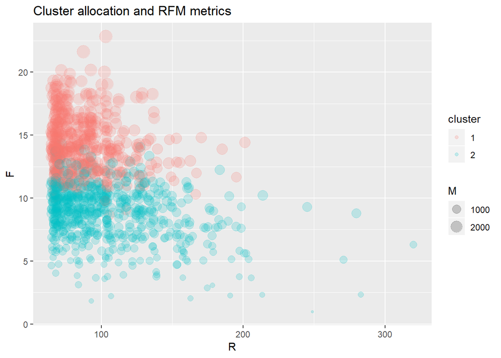

```r
RFM_clust %>%
    ggplot(aes(x = R, y = F, size = M,color = cluster)) +
    geom_jitter(alpha = .2) + #scale_size(range=c(1,10)) +
    labs(title = 'Cluster allocation and RFM metrics')
```

The interpretation of the two clusters can be seen as **high-potential** and **low-potential** customers.

# 4 Classification

## 4.1 Load data

In order to predict cluster allocation of future customers, we need a demographic dataset about our existing customer portfolio.

We load the following set consisting of the attributes

1. Marital Status
2. Age
3. Sex
4. Education

We try to find a relationship between these attributes and the cluster segment to which a customer belongs via training a supervised learning algorithm.

```r
customers <- read_csv2('data/customers_sim.csv') %>%
    mutate_at(vars(CustomerID, MaritalStatus, Sex, Education), as.factor)
customers
```

| CustomerID | Age | MaritalStatus | Sex | Education |
| --- | --- | --- | --- | --- |
| 1002 | 42 | Married | Male | High School |
| 1003 | 71 | Married | Female | Master |
| 1004 | 26 | Married | Female | High School |
| 1005 | 25 | Married | Male | High School |
| 1006 | 65 | Married | Male | High School |
| 1010 | 48 | Married | Male | High School |
| 1011 | 79 | Married | Female | High School |
| 1013 | 52 | Married | Female | Bachelor |
| 1015 | 45 | Divorced | Male | Bachelor |
| 1017 | 97 | Married | Male | High School |

[output cut: 1079 more lines]

Structure of the dataset:

```r
str(customers)
```

```
## Classes 'tbl_df', 'tbl' and 'data.frame':    1089 obs. of  5 variables:
##  $ CustomerID   : Factor w/ 1089 levels "1002","1003",..: 1 2 3 4 5 9 10 12 14 16 ...
##  $ Age          : int  42 71 26 25 65 48 79 52 45 97 ...
##  $ MaritalStatus: Factor w/ 3 levels "Divorced","Married",..: 2 2 2 2 2 2 2 2 1 2 ...
##  $ Sex          : Factor w/ 2 levels "Female","Male": 2 1 1 2 2 2 1 1 2 2 ...
##  $ Education    : Factor w/ 3 levels "Bachelor","High School",..: 2 3 2 2 2 2 2 1 1 2 ...
```

## 4.2 Preprocessing

### 4.2.1 Joining the cluster allocation

We need to add the column **cluster** from our previous analysis to the demographic dataset. The join is done over the common field **CustomerID**.

```r
modeldat <- customers %>%
    inner_join(RFM_clust) %>%
    select(-CustomerID, -R, -F, -M)
modeldat
```

| Age | MaritalStatus | Sex | Education | cluster |
| --- | --- | --- | --- | --- |
| 42 | Married | Male | High School | 2 |
| 71 | Married | Female | Master | 2 |
| 26 | Married | Female | High School | 2 |
| 25 | Married | Male | High School | 2 |
| 65 | Married | Male | High School | 2 |
| 48 | Married | Male | High School | 2 |
| 79 | Married | Female | High School | 2 |
| 52 | Married | Female | Bachelor | 2 |
| 45 | Divorced | Male | Bachelor | 2 |
| 97 | Married | Male | High School | 2 |

[output cut: 1079 more lines]

### 4.2.2 Splitting

We split the joined dataframe in training- and testset using a stratified splitting strategy on variable **cluster**, in order to retain an even distribution of both clusters in both sets.

```r
intrain <- createDataPartition(modeldat$cluster, p = .8, list=FALSE)

training <- modeldat[intrain,]
testing <- modeldat[-intrain,]
```

## 4.3 Model training

We activate 10-fold Cross-Validation for the training procedures.

```r
trControl <- trainControl(method = 'cv')
fit <- list()
```

We will fit three different models.

### 4.3.1 Logistic regression

```r
fit$glm <- train(cluster ~ .,
                       method="glm",
                       family="binomial",
                       trControl = trControl,
                       data = training)

fit$glm
```

```
## Generalized Linear Model
##
## 872 samples
##   4 predictor
##   2 classes: '1', '2'
##
## No pre-processing
## Resampling: Cross-Validated (10 fold)
## Summary of sample sizes: 785, 784, 785, 785, 785, 785, ...
## Resampling results:
##
##   Accuracy   Kappa
##   0.9128265  0.823225
```

### 4.3.2 Partition tree

```r
fit$rpart <- train(cluster ~ .,
                       method="rpart",
                       trControl = trControl,
                       data = training,
                       tuneLength = 10)

fit$rpart
```

```
## CART
##
## 872 samples
##   4 predictor
##   2 classes: '1', '2'
##
## No pre-processing
## Resampling: Cross-Validated (10 fold)
## Summary of sample sizes: 785, 785, 784, 785, 785, 785, ...
## Resampling results across tuning parameters:
##
##   cp          Accuracy   Kappa
##   0.00000000  0.9118582  0.8213897
##   0.06291486  0.8923170  0.7834229
##   0.12582973  0.8923170  0.7834229
##   0.18874459  0.8798170  0.7593154
##   0.25165945  0.8086556  0.6234743
##   0.31457431  0.8086556  0.6234743
##   0.37748918  0.8086556  0.6234743
##   0.44040404  0.8086556  0.6234743
##   0.50331890  0.8086556  0.6234743
##   0.56623377  0.6658061  0.2762678
##
## Accuracy was used to select the optimal model using the largest value.
## The final value used for the model was cp = 0.
```

### 4.3.3 Boosted trees

```r
fit$gbm <- train(cluster ~ .,
                       method="gbm",
                       trControl = trControl,
                       data = training,
                       tuneLength = 10,
                 verbose =F)

fit$gbm
```

```
## Stochastic Gradient Boosting
##
## 872 samples
##   4 predictor
##   2 classes: '1', '2'
##
## No pre-processing
## Resampling: Cross-Validated (10 fold)
## Summary of sample sizes: 784, 785, 784, 784, 785, 785, ...
## Resampling results across tuning parameters:
##
##   interaction.depth  n.trees  Accuracy   Kappa
##    1                  50      0.9164419  0.8305919
##    1                 100      0.9175385  0.8332359
##    1                 150      0.9117904  0.8217131
```

[output cut: 104 more lines]

# 5 Model Evaluation

## 5.1 Performance on training set

We collect the resamples of all three fitted models and plot the distribution of the performance statistics **Accuracy** and **Cohen’s Kappa**.

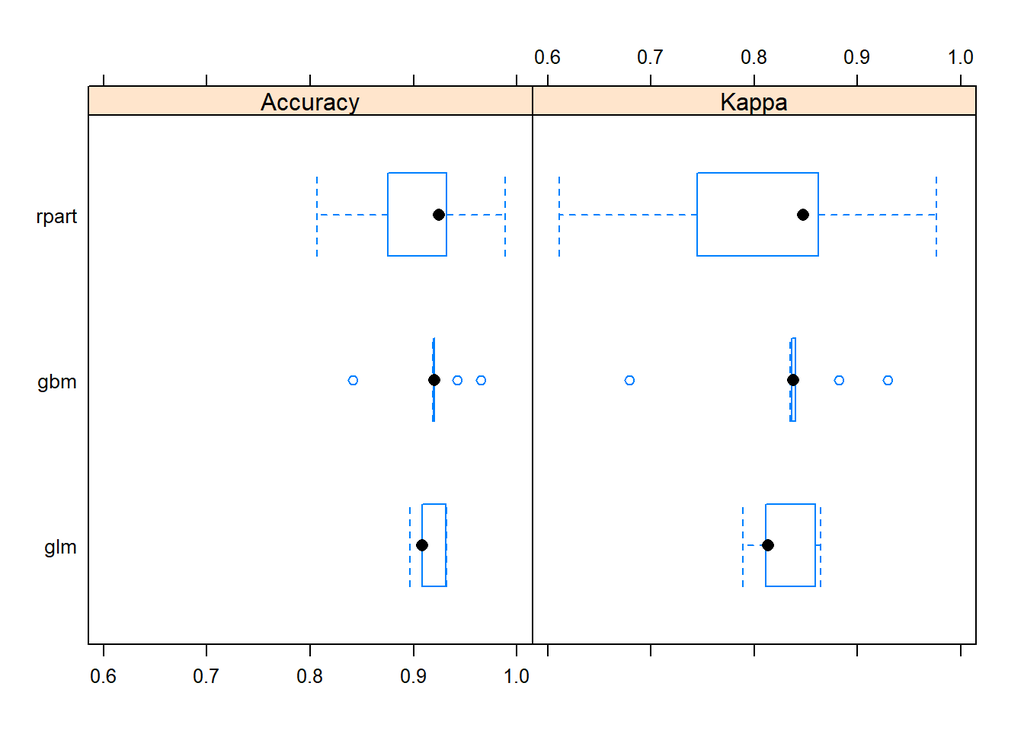

```r
rs <- resamples(fit)
bwplot(rs)
```

## 5.2 Performance on test set

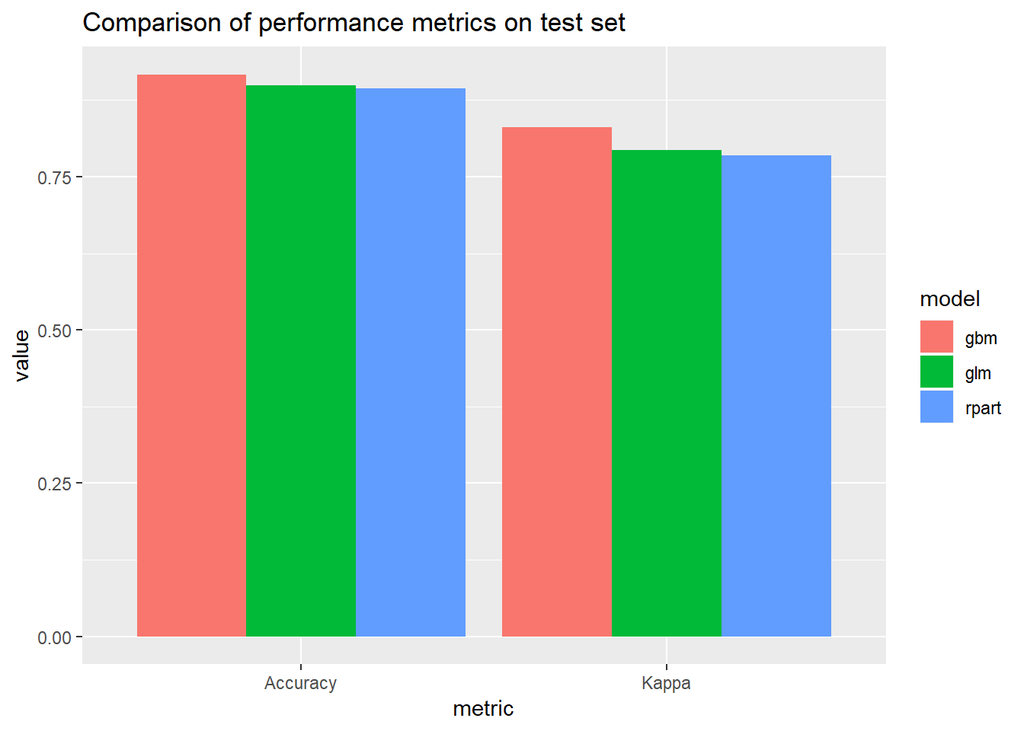

```r
prediction <- lapply(fit, predict, newdata = testing) %>%
    bind_cols()

prediction %>%
    sapply(postResample, obs = testing$cluster) %>%
    as.data.frame() %>%
    rownames_to_column('metric') %>%
    gather(model, value, -metric) %>%
    ggplot(aes(x=metric, y = value, fill = model)) +
    geom_col(position='dodge') +
    labs(title='Comparison of performance metrics on test set')
```

Showing the confusion matrix of the decision tree model on the test set.

```r
predict(fit$rpart, testing) %>%
    confusionMatrix(testing$cluster)
```

```
## Confusion Matrix and Statistics
##
##           Reference
## Prediction   1   2
##          1  85  12
##          2  11 109
##
##                Accuracy : 0.894
##                  95% CI : (0.8452, 0.9316)
##     No Information Rate : 0.5576
##     P-Value [Acc > NIR] : <2e-16
##
##                   Kappa : 0.7854
##  Mcnemar's Test P-Value : 1
##
##             Sensitivity : 0.8854
##             Specificity : 0.9008
##          Pos Pred Value : 0.8763
##          Neg Pred Value : 0.9083
##              Prevalence : 0.4424
##          Detection Rate : 0.3917
##    Detection Prevalence : 0.4470
##       Balanced Accuracy : 0.8931
##
##        'Positive' Class : 1
##
```

Visualizing the decision tree.

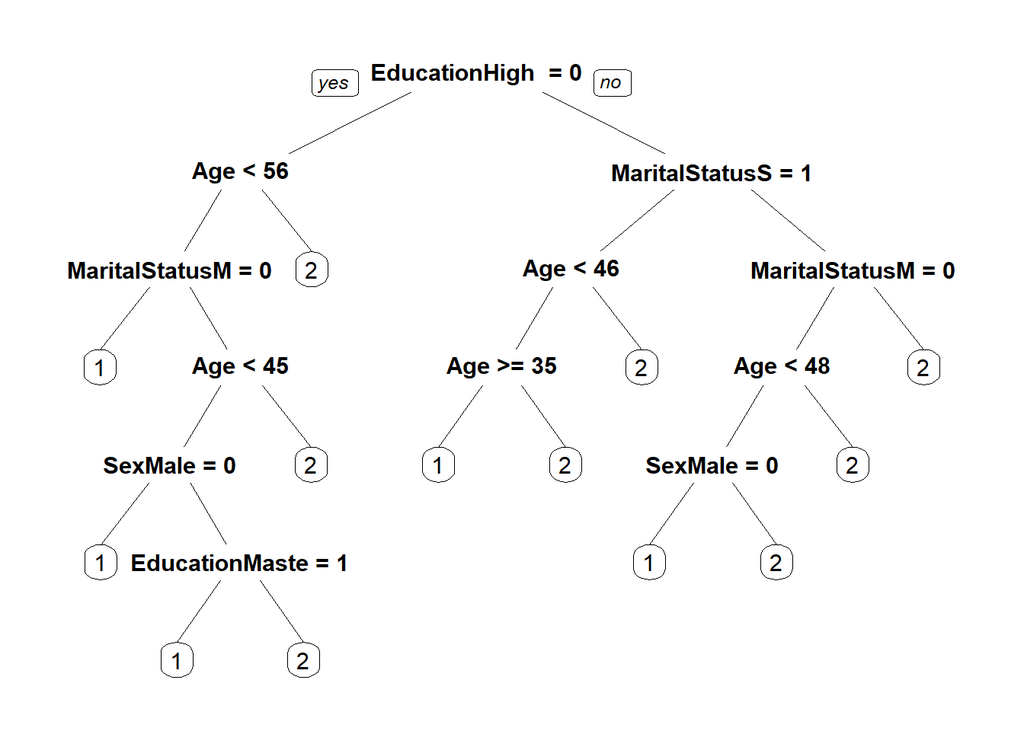

[figure not shown]

```r
fit$rpart$finalModel %>% prp()
```